# Some example functions to work on

Joseph Crispell

23 May 2018

## Why write functions?

A function is a stand-a-lone piece of code designed to complete a single task. A function has inputs and usually produces an output, it generally takes the form:

```r
functionName <- function(input(s)){

  # Write R code to a set of tasks here

  # Return something from the function - OPTIONAL
  return(output)
}
```

By restricting functions to single tasks, developing code becomes more manageable and efficient. The stand-a-lone aspect of a function is one of its main benefits, it can be developed and tested without relying upon any other code and, once ready, easily incorporated into other functions.

Here we are going to be developing a whole series of functions, to do simple tasks within R. Most of the functions have already been developed and are available directly within R but hopefully by writing them ourselves we’ll learn a bit more about the importance of functions and programming in general.

## General functions to work on

Here, we work on creating some of the functions that already exist within R, which we often take for granted. The aim here isn’t the re-invention of the wheel but it is to teach us about creating functions. Having the functions already available within R will allow us to very easily test our work.

### Find the maximum

Write a function that, given a vector of numbers as input, will return the maximum value present in the vector.

### Repeat a value X times

Write a function that, given a value and an integer specifying how many times the value is to be repeated, will return a vector containing the value repeated the specified number of times.

### Add two vectors together

Write a function that, given two vectors of numbers ($a$, and $b$) as input, will return a single vector ($output$) where:
$$output[i] = a[i] + b[i]$$
Although there are much better ways to do this, in your function you should use a `for` loop.

### Check if value is in vector

Write a function that, given a vector and a value as input, checks whether the value is present in the vector.

### Get the current date

Write a function that will return the current date as a string, in the format: dd-mm-yy. You are allowed to use the `Sys.Date()` and `format.Date()` functions.

### Reverse a vector

Write a function that, given an vector of values, will return a vector of the same values but in reverse order.

### Sequence of numbers

Write a function that, given start, end, and step values as input, will return a sequence of numbers starting at the specified start and ending on or before the specified end, incrementing by the specified step value.

### Calculate the euclidean distance between two points

Write a function that, given X and Y coordinates for two points (in the form: $x1$, $y1$, $x2$, $y2$), will return the euclidean (stright line) distance between the points.

### Find the unique values

Write a function that, given a vector as input, will return a vector containing only the unique values present in the input vector.

### Find the unique values in the vector and count how many times each is found

Write a function that, given a vector as input, will find each of the unique values in that vector and count how many times each value is present in the vector. This function should replicate the `table()` function in R.

### Create copy of vector values, without a particular value or values

Write a function that, given a vector and a value as input, returns a vector without the input value present.

### Calculate the mean of rows or columns in matrix

Write a function that, given a matrix and boolean choice variable as input, will return a vector containing the means of each row or column in the input matrix. The boolean choice variable, called “byRow” (`TRUE/FALSE`), will be set by the user to decide whether the want the means of the rows (byRow=`TRUE`) or columns (byRow=`FALSE`). The “byRow” input parameter should be set to `TRUE` by default.

## Plotting functions to work on

Here, we’ll get a little practice in for sampling from and plotting distributions. You are allowed to use the base (no packages) for these tasks.

### Plot a sample from a normal distribution

Plot a sample (n=1000) of a normal distribution with a mean of 5 and a standard deviation of 3. State in the legend the values used for the mean and standard deviation. It should look like this:

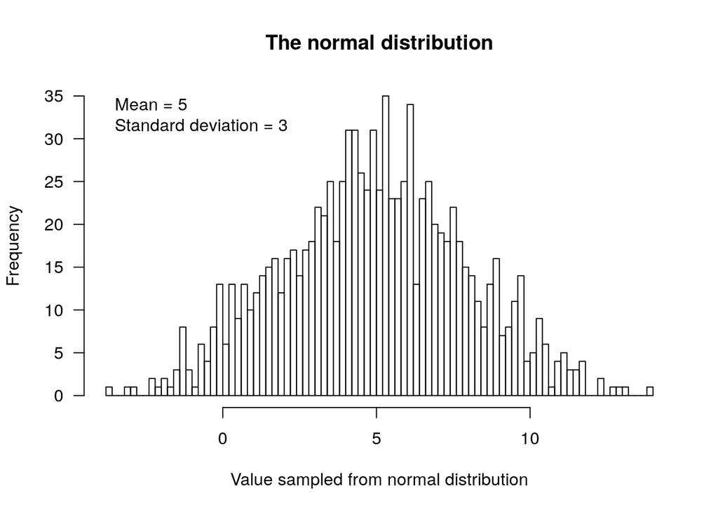

### Plotting samples from a Poisson distribution

Plot a sample (n=1000) of a Poisson distribution with a mean of 2, stating the value used for the mean in the legend. On the same plotting panel, add a plot of a sample from a Poisson distribution with a mean of 10.

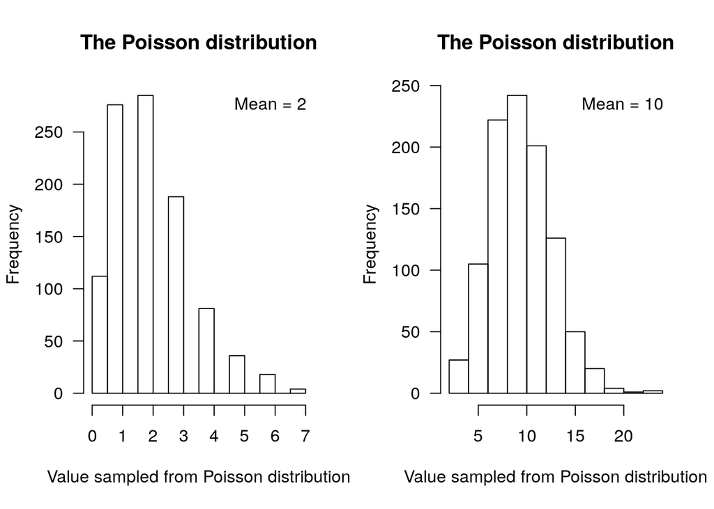

Write a few notes detailing why these plots look so different, even though they are drawn from the same distribution and only the mean has changed.

# Comparing samples from Normal distributions

Create a boxplot to compare two samples from a normal distribution each with a mean of 10, but one with a standard deviation of 1 and the other with a standard deviation of 5. It should look something like this (see if you can match the colours):

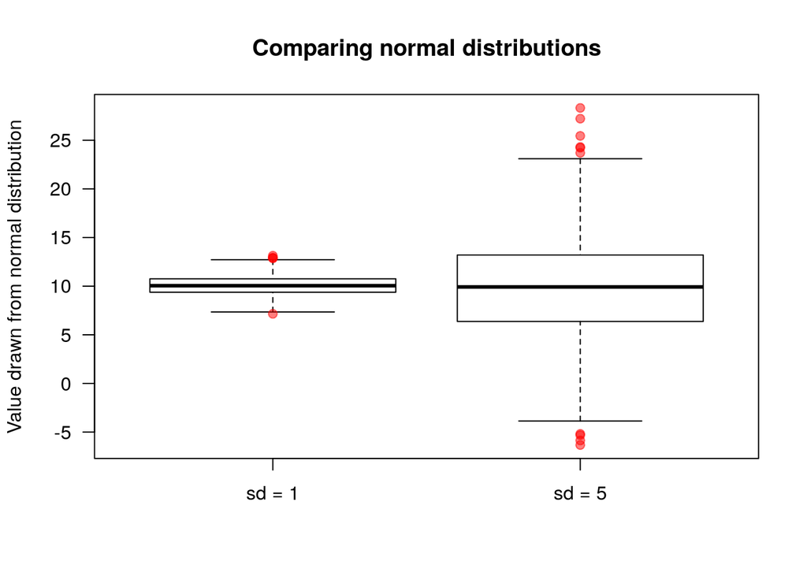

Write a few notes detailing the differences, and their cause, between these two sample normal distributions.